# Communicate Findings About Loan Data from prosper

## by (Vedavyas Kamath)

## Preliminary Wrangling

### What is the structure of your dataset?

> The dataset contains a total of 113937 entries for loans along with 81 attributes for each loan. Each loan contains loan details like (Status, Principal, period of loan, APR) along with the borrowerer's background details like (occupation, income, employment status, Available Credit Limit, Income range).

### What is/are the main feature(s) of interest in your dataset?

> The main feature in the dataset that caught my eye were LoanStatus, BorrowerRate, ProsperScore variable.

### What features in the dataset do you think will help support your investigation into your feature(s) of interest?

> The main features in the dataset seem to be the IncomeRange, ProsperScore, CreditScore (Upper and lower), AvailableBankCredit, Occupation & Employment Status, Home Ownership which we can expect to have an effect on a loand being defulted!

## Univariate Exploration

## 1. Top 10 occupations of borrowers

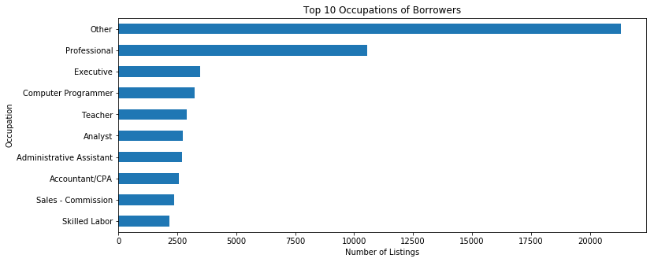

```python
#set the figure size:
plt.figure(figsize = [12, 5])

#Plot a horizontal bar chart for top 10 occupations with highest counts:
df['Occupation'].value_counts()[9::-1].plot(kind='barh')

#Set the x-label, y-label, chart title and font size:
plt.title('Top 10 Occupations of Borrowers')
plt.xlabel('Number of Listings')
plt.ylabel('Occupation')
plt.fontsize = 13
```

#### Insights:

> From the plot, we can see that most number of listings are by people who belonged to 'Other' occupations followed by 'Professional'. The reason for people selecting occupation as 'Others' may be justified by below 2 points:
> 1. These people may have been doing odd jobs which are not mainstream occupations that people take up.
> 2. People may not want to disclose their actual occupation and so have listed it as 'Other'.

## 2. Distribution of Income Range of Borrowers

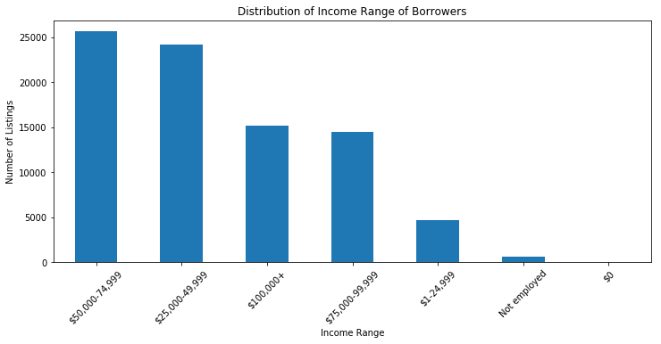

```python
#set the color and figure size
color = sb.color_palette()[0]
plt.figure(figsize = [12, 5])

#plot a bar chart for income range by using the values and counts stored above:
income_range.plot(kind='bar', color=color);

#Set the x-label, y-label, chart title and font size:
plt.title('Distribution of Income Range of Borrowers');
plt.xlabel('Income Range');
plt.ylabel('Number of Listings');
plt.xticks(rotation=45);
plt.fontsize = 13;
```

## 3. Count of listings by state:

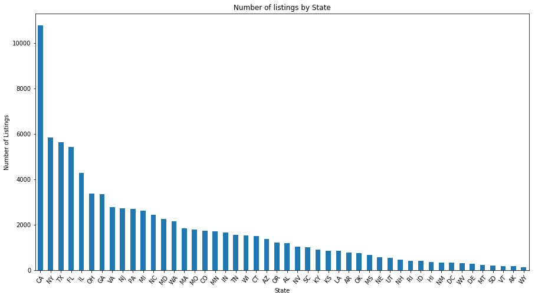

```python
#set the color and figure size:
color = sb.color_palette()[0]
plt.figure(figsize=(15, 8))

#Plot a bar chart for all states with their respective counts:
states_count.plot(kind='bar', color=color);

#Set the x-label, y-label, chart title and font size:
plt.title('Number of listings by State');
plt.xlabel('State');
plt.ylabel('Number of Listings');
plt.xticks(rotation=50);
plt.fontsize = 13
```

#### Insights:

> From the plot, we can see that most number of listings were in the state of California followed by next state NY. This maybe due to the fact that there are a lot of Universities in the state of California along with the Silicon Valley which is based in this state. So we can expect a lot of students to apply for loans prior to enrolling into their courses in these Universities along with businessmen who may take loans to fund their tech startups!

## 4. Distribution of ProsperScore:

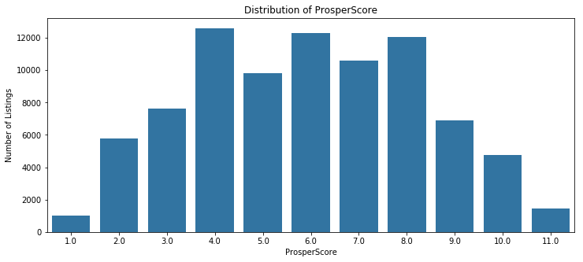

```python
#set the color and figure size:
plt.figure(figsize = [12, 5])
color = sb.color_palette()[0]

#plot a bar chart for all values of prosper score included in the dataset which was stored in the variable above:
sb.countplot(data = df, x = 'ProsperScore', color = color);

#Set the x-label, y-label, chart title and font size:
plt.title('Distribution of ProsperScore')
plt.ylabel('Number of Listings')
plt.xlabel('ProsperScore')
plt.fontsize = 13
```

#### Insights:

> From the plot, we can see that most number of listings had a ProsperScore of 4.0, 6.0 and 8.0 respectively. Overall we can say that maximum number of listings were in the range of 4.0 to 8.0

## 5. Number of Listings by Loan Status:

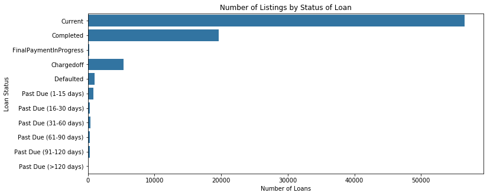

```python
#set the color and figure size:
plt.figure(figsize = [12, 5])
color = sb.color_palette()[0]

#Plot a horizontal bar chart with counts of all values of loan status present in the dataset by setting the order of levels
#as defined above:
sb.countplot(data = df, y = 'LoanStatus', order =status_order, color = color);

#Set the x-label, y-label, chart title and font size:
plt.title('Number of Listings by Status of Loan')
plt.xlabel('Number of Loans')
plt.ylabel('Loan Status')
plt.fontsize = 13
```

#### Insights:

> The number of listings for each Loan Status can be seen in the plot above which shows that maximum number of listings are Currently ongoing followed by Completed listings and Chargedoff listings. Other statuses which include dues for various intervals, along with cancelled listings are very few in number.

## 6. Distribution of AvailableBankcardCredit

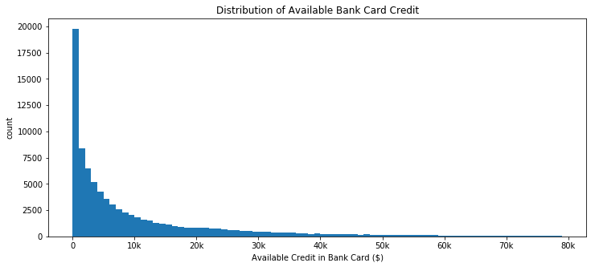

```python
#set thefigure size:
plt.figure(figsize = [12, 5])

#Further could see majority lies between 0 and $60,000. Thus, zooming further into data by changing the range and ticks:
#changed the bins to see data only uptill $80,000
bins = np.arange(0, 80000, 1000)
plt.hist(data = df, x = 'AvailableBankcardCredit', bins = bins)

#changed values to displayed on x axis from 0 to $80,000
plt.xticks([0, 1e4, 2e4, 3e4, 4e4, 5e4, 6e4, 7e4, 8e4],
           [0, '10k', '20k', '30k', '40k', '50k', '60k','70k','80k'])

#Set the x-label, y-label, chart title and font size:
plt.title('Distribution of Available Bank Card Credit')
plt.xlabel('Available Credit in Bank Card ($)')
plt.ylabel('count');
plt.fontsize = 13
```

#### Insights:

> From the plot we can conclude that this variable is heavily right-skewed. Initially, we could see that the available bank credit for most of the borrowers at time the credit was pulled is between USD 0 and 20,000. Upon further zooming into the data could see that USD 0 to 1000 is the available bank credit card for most of the people when their profiles were pulled!

## 7. Distribution of Credit Score range (Upper and Lower):

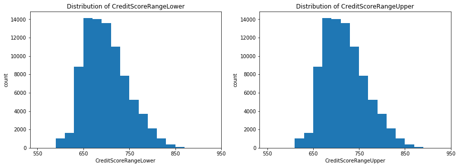

```python
#set thefigure size:
plt.figure(figsize = [15, 5])

#plotting 2 plots side by side 1st one showing histogram for lower bound of Credit Score and 2nd showing for upper bound:

plt.subplot(1, 2, 1)  #Code to plot the histogram plot for CreditScoreRangeLower on left side (1st plot)
bins = np.arange(550, df['CreditScoreRangeLower'].max(), 20)
plt.hist(data = df, x = 'CreditScoreRangeLower', bins = bins)
plt.xticks(np.arange(550, 1000, 100))
#Set the x-label, y-label, chart title and font size:
plt.title('Distribution of CreditScoreRangeLower')
plt.xlabel('CreditScoreRangeLower')
plt.ylabel('count');
plt.fontsize = 13

plt.subplot(1, 2, 2)  #Code to plot the histogram plot for CreditScoreRangeLower on the right side (2nd plot)
bins = np.arange(550, df['CreditScoreRangeUpper'].max(), 20)
plt.hist(data = df, x = 'CreditScoreRangeUpper', bins = bins)
plt.xticks(np.arange(550, 1000, 100))
#Set the x-label, y-label, chart title and font size:
plt.title('Distribution of CreditScoreRangeUpper')
plt.xlabel('CreditScoreRangeUpper')
plt.ylabel('count');
plt.fontsize = 13

#NOTE: Keeping the same scale on X-axis i.e. bins & values displayed to be able to compare both variables easily
```

#### Insights:

> We can see that distributions for both uper and lower credit score show simillar trends. Both distributions are slightly right-skewed with the most frequent value being in the range of 650 to 710 for lower bound of credit score and 670 to 730 for the upper bound of credit score.

## Bivariate Exploration

## 1. Relationship between Prosper Score and Loan Status:

[figure not shown]

```python
#set thefigure size and color:
plt.figure(figsize = [12, 5])
base_color = sb.color_palette()[0]

#Plot the box plot for different values of Loan Status against the ProsperScore in order of levels defined above:
sb.boxplot(data = df, x = 'ProsperScore', y = 'LoanStatus', color = base_color, order = status_order);

#Set the values to be displayed on axis as per range of valus in ProsperScore variable in dataset i.e. (1 to 11)
plt.xticks(np.arange(0, 11+1, 1));

#Set the x-label, y-label, chart title and font size:
plt.xlabel('LoanStatus')
plt.ylabel('ProsperScore')
plt.title('Relationship between Prosper Score and Loan Status')
plt.fontsize = 13
```

#### Insights:

> From this plot we can say that borrowers with higher prosper ratings tended to complete the loan without defaulting. We see a higher median of prosper score for people who completed he loan. Thus, people with lower prosper ratings are more likely to not pay back the loan in time. Borrowers who have not paid the loan past due date more than 120 days seem to have the lowest range of prosper rating.

## 2. Change in Interest rate (BorrowerRate) over time:

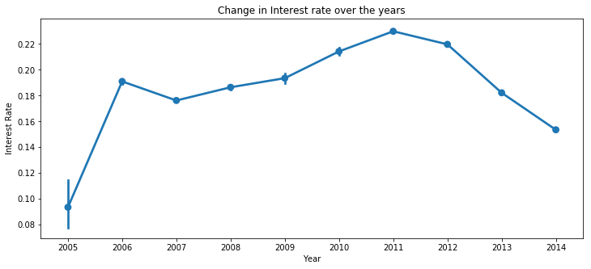

```python
#set the figure size:
plt.figure(figsize = [12, 5])

#Building a line plot using counts of disitinct year values calculated as before:
sb.pointplot(data=df_loans, x='year', y='BorrowerRate');

#Set the x-label, y-label, chart title and font size:
plt.xlabel('Year');
plt.ylabel('Interest Rate');
plt.title('Change in Interest rate over the years');
plt.fontsize = 13
```

#### Insights:

> From the above plot, we can see that the interest rate was very low initially in 2005 and shot up exponentially in 2006. Then in 2007 there was a slight drop in the rate after which the interest rates began to climb steadily untill 2011. The highest interest rate observed was in 2011. The rates then began to fall down steadily from 2012 onwards till 2014.

## 3. Relationship between AvailableBankcardCredit and BorrowerRate

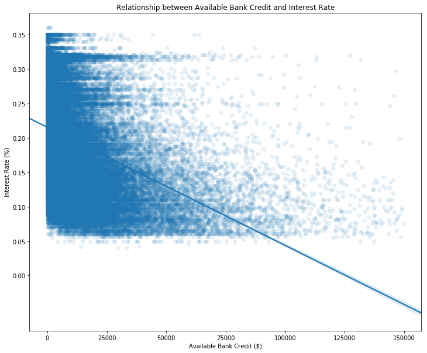

```python
#set the figure size:
plt.figure(figsize = [12, 10])

#Built a regression plot with a regression line so that the trend can be easily observed:
#as there were a lot of points in the range of 0-$50,000, added some transperency by setting 'alpha' parameter
sb.regplot(data = df_2, x = 'AvailableBankcardCredit', y = 'BorrowerRate',   fit_reg = True, scatter_kws = {'alpha':0.1});

#Set the values to be dsiplayed on x-axis and y-axis so that data is displayed clearly:
plt.yticks([0, 0.05, 0.10, 0.15, 0.20, 0.25, 0.3, 0.35]);
plt.xticks([0, 25000, 50000, 75000, 100000, 125000, 150000]);

#Set the x-label, y-label and chart title and font-size:
plt.title('Relationship between Available Bank Credit and Interest Rate')
plt.xlabel('Available Bank Credit ($)');
plt.ylabel('Interest Rate (%)');
plt.fontsize = 13
```

#### Insights:

> It is clear from the plot and the slope of the regression line that there is a negative co-relation between the Available Bank Credit and the Interest rate. Borrowers having high amount of bank credit are given loans at lower interest rates as compared to people with lower interest rates who are charged a higher rate.

### Talk about some of the relationships you observed in this part of the investigation. How did the feature(s) of interest vary with other features in the dataset?

> Could see that ProsperScore did infact have a relation in deciding whether or not a loan was going to be defaulted. It was observed that borrowers with a higher ProsperScore tended to pay back the loans back in time without defaulting. Simillarly, as expected by logically thinking, could see that borrowers with a higher available bank credit were seen to be getting loans at a compartively lesser interest rate.

## Multivariate Exploration

## 1. Comparison of Interest Rates by Employment Status & Home Ownership

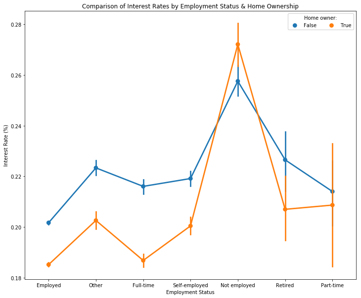

```python
#set the figure size:
plt.figure(figsize = [12, 10])

#Plotted a line plot so that Interest Rates for different levels of Employment status are displayed clearly for
#both values of Homeowners as well as non-home owners:
#selected homeowner variable to be displayed through colour encoding because it would be easy to interpret
#as it has only 2 distinct levels.
ax = sb.pointplot(data = df, x = 'EmploymentStatus', y = 'BorrowerRate', hue = 'IsBorrowerHomeowner');

#set the legend to be displayed with values for Home Owner variable:
ax.legend(ncol = 3, framealpha = 1, title = 'Home owner:');

#Set the x-label, y-label and chart title and fontsize:
plt.xlabel('Employment Status')
plt.ylabel('Interest Rate (%)')
plt.title('Comparison of Interest Rates by Employment Status & Home Ownership')
plt.fontsize = 13
```

#### Insights:

1. From the above plot, we can clearly see that the interest rates are highest for Unemployed Borrowers and the least for borrowers who are Employed.
2. Borrowers who are Unemployed, Retired or have mentioned status as others are given loans with comparitively higher interest rates as compared to the borrowers in other categories.
3. We can see a simillar trend for house owners as well as non-house owners, except for Borrowers who are Unemployed.
4. We can see that except for Unemployed borrowers, borrowers who are house-owners are charged lower interest rates as compared to non-house owners.
5. Only those house owners who are unemployed seem to be getting loans at higher interest rates.

## 2. Comparison of Available Bank Card Credit amount by Employment Status & Home Ownership

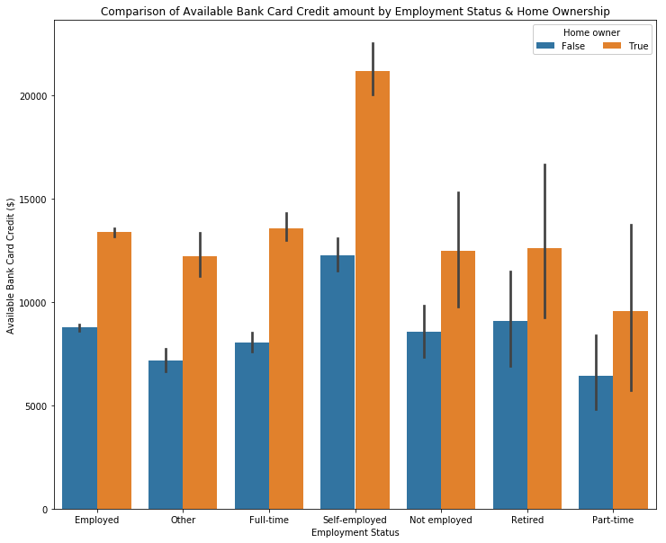

```python
#set the figure size:
plt.figure(figsize = [12, 10])

#Plotted a line plot so that Available Bank Credit for different levels of Employment status are displayed clearly for
#both values of Homeowners as well as non-home owners:
#selected homeowner variable to be displayed through colour encoding because it would be easy to interpret
#as it has only 2 distinct levels.
ax = sb.barplot(data = df, x = 'EmploymentStatus', y = 'AvailableBankcardCredit', hue = 'IsBorrowerHomeowner');

#set the legend to be displayed with values for Home Owner variable:
ax.legend(ncol = 3, framealpha = 1, title = 'Home owner');

#Set the x-label, y-label and chart title:
plt.xlabel('Employment Status')
plt.ylabel('Available Bank Card Credit ($)')
plt.title('Comparison of Available Bank Card Credit amount by Employment Status & Home Ownership')
plt.fontsize = 13
```

#### Insights:

1. The overall trend looks to be the same for Home-owners as well as non-home owners.
2. We can see that the Self-Employed borrowers seem to have the highest amount of Bank Card Credit Available and Part-Time working borrowers having the least.
3. We can also see that borrowers who are Home-Owners tend to have a higher available bank credit as compared to Non-Home owners.

## Corelation Plot Using Heat Map

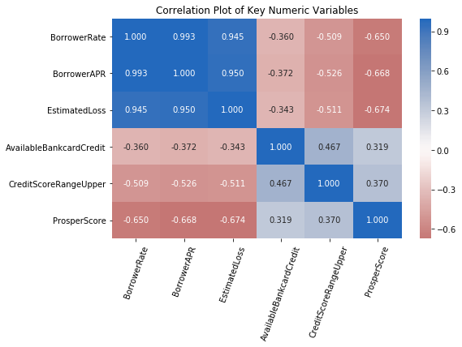

```python
# correlation plot using Heat-Map:

#Created a list of numeric variables only that need to be checked for co-relation with other variables:
numeric_vars = ['BorrowerRate', 'BorrowerAPR', 'EstimatedLoss','AvailableBankcardCredit','CreditScoreRangeUpper','ProsperScore']

#set the figure size
plt.figure(figsize = [8, 5])

#Plotted the heat map by subsetting the newly subseted df by passing only the numeric variables listed above
sb.heatmap(df_new[numeric_vars].corr(), annot = True, fmt = '.3f',
           cmap = 'vlag_r', center = 0)

#Rotated the values on x-axis slight for easier understanding:
plt.xticks(rotation = 70);

#Set the fontsize plot title:
plt.fontsize = 13
plt.title('Correlation Plot of Key Numeric Variables')
plt.show()
```

#### Insights:

1. From the above we can see a strong positive co-relation between Interest Rate, APR and the Estimated Loss variables. This shows that the for Higher Interest rate, the APR is also high but is expected to make more loss also. This could be the reason why we are seeing a fall in the interest rates over the years.
2. We also saw positive co-relation (not very strong) i.e. low to moderate between Prosper Score Credit Score and the Available Bank credit. This was expected as borrowers with high bank credit available will also tend to NOT default while making payments and would end up having a higher Credit Score.
3. We observed negative corelation of Estimated Loss with ProsperScore, CreditScore and AvailableBankCredit. This makes sense as borrowers with financially sound background are likely to pay of the loan in time and not be charged-off.

## Plot Matrix

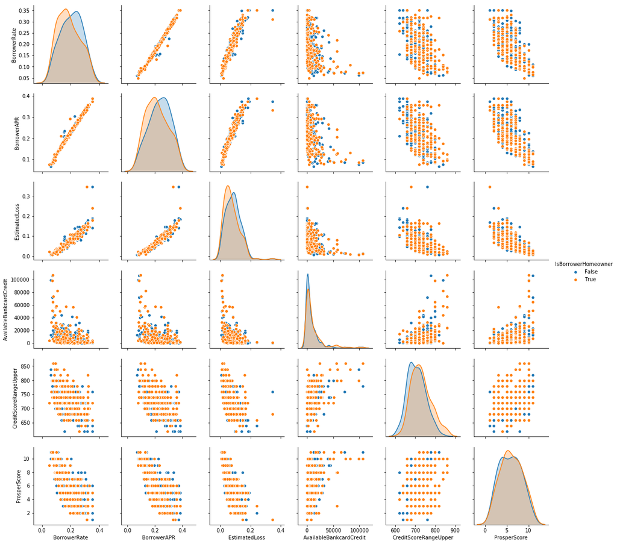

```python
#Now we make a plot matrix to observe relationship between all the numeric variables seen in corelation plot above while also
#using color encoding to incorporate another categoric variable: IsBorrowerHomeowner to show how data for homeowners &
#non-homeowners compare

#Created a list of numeric variables only that need to be plotted to see direct relationship with other variables:
numeric_vars = ['BorrowerRate', 'BorrowerAPR', 'EstimatedLoss','AvailableBankcardCredit','CreditScoreRangeUpper','ProsperScore']

#As there are a lot of data points, taking a sample of the data to be able to observe trends more clearly:
samples = np.random.choice(df_new.shape[0], 500, replace = False)
sample_df = df_new.loc[samples,:]

#Create the Pairplot to see relationship between 6 numeric variables used in corelation plot and also 1 additional categoric variable:
sb.pairplot(sample_df, vars = numeric_vars, hue="IsBorrowerHomeowner");
```

#### Insights:

1. We can clearly observe relationships/trends which are analgous to the value of co-relation we observed for variables in the corelation heatmap above.
2. In this plot we have incorporated an additional categoric variable for Home Ownership in our analysis and we can observe a simillar trend for homeowners as well as non-homeowners.

### Talk about some of the relationships you observed in this part of the investigation. Were there features that strengthened each other in terms of looking at your feature(s) of interest?

> Observed a relationship between employment status and home ownership from the multivariate analysis to see the effect on interest rate and available bank credit. It can be seen that employed borrowers who also own homes are considered to be financially sound (just as we would think logically) and are given loans more easily that too at lesser interest rates since they seem to also have higher amount of available bank credit than the unemployed borrowers who dont own homes! The reason for this could be that home owners can keep their house on mortgage (as a security), so that the loan amount can be recovered in case the borrower defaults to pay the loan in time!

> Additionally, from the corelation plot and plot matrix, could see that high interest rates are proportional and could lead to higher amount of losses, which maybe a reason that explains why interest rates are falling through the years!